Model selection- Linear Regression

# About the dataset

The dataset consists of 804 entries and 11 variables.The data corresponds to different institutions and their respective details.The variables are  
1.tuition- fees for that institute  
2.pcttop25- rating  
3.sf_ratio- student ratio  
4.fac_comp  
5.accrate  
6.graduat- number of graduates  
7.pct_phd- number of phd students  
8.fulltime- number of fulltime students  
9.num_enroll- total enrolled students  
10.public.private- public or private institute

# Overview of data

Summary statistics of all variables

```
##   tuition pcttop25 sf_ratio fac_comp accrate graduat pct_phd fulltime
## 1    4440       78     18.9    47700   0.660      51      72    87.81
## 2    6300       57     16.7    54600   0.900      69      85    90.46
## 3    4104       46     25.3    54800   0.735      50      94    63.21
## 4   11660       88     14.0    52300   0.730      72      74    86.92
## 5    2970       40     19.4    50300   0.646      76      62    78.49
## 6    8080       47     11.4    36600   0.855      44      63    81.02
##   alumni num_enrl public.private
## 1      8      570              0
## 2     18     3070              0
## 3      3     1686              0
## 4     34      287              1
## 5      5      625              0
## 6      9      127              1
```

```
## 'data.frame':    804 obs. of  11 variables:
##  $ tuition       : int  4440 6300 4104 11660 2970 8080 9550 6150 4860 5504 ...
##  $ pcttop25      : int  78 57 46 88 40 47 24 54 47 75 ...
##  $ sf_ratio      : num  18.9 16.7 25.3 14 19.4 11.4 14.1 16.6 17.4 17.7 ...
##  $ fac_comp      : int  47700 54600 54800 52300 50300 36600 34200 36300 50300 46000 ...
##  $ accrate       : num  0.66 0.9 0.735 0.73 0.646 0.855 0.981 0.732 0.909 0.621 ...
##  $ graduat       : int  51 69 50 72 76 44 58 52 43 73 ...
##  $ pct_phd       : int  72 85 94 74 62 63 64 59 103 71 ...
##  $ fulltime      : num  87.8 90.5 63.2 86.9 78.5 ...
##  $ alumni        : int  8 18 3 34 5 9 18 4 16 37 ...
##  $ num_enrl      : int  570 3070 1686 287 625 127 222 269 243 806 ...
##  $ public.private: int  0 0 0 1 0 1 1 1 0 1 ...
```

```
##     tuition         pcttop25         sf_ratio        fac_comp
##  Min.   : 2340   Min.   : 11.00   Min.   : 2.50   Min.   :26500
##  1st Qu.: 7146   1st Qu.: 40.00   1st Qu.:11.50   1st Qu.:44700
##  Median : 9842   Median : 54.00   Median :13.75   Median :52150
##  Mean   :10295   Mean   : 55.32   Mean   :14.24   Mean   :53714
##  3rd Qu.:12850   3rd Qu.: 68.25   3rd Qu.:16.70   3rd Qu.:60925
##  Max.   :25750   Max.   :100.00   Max.   :39.80   Max.   :98900
##     accrate          graduat          pct_phd          fulltime
##  Min.   :0.1540   Min.   : 10.00   Min.   :  8.00   Min.   :11.43
##  1st Qu.:0.6790   1st Qu.: 52.00   1st Qu.: 62.75   1st Qu.:71.37
##  Median :0.7790   Median : 65.00   Median : 75.00   Median :85.28
##  Mean   :0.7494   Mean   : 64.78   Mean   : 73.04   Mean   :80.90
##  3rd Qu.:0.8490   3rd Qu.: 77.00   3rd Qu.: 85.00   3rd Qu.:93.71
##  Max.   :1.0000   Max.   :118.00   Max.   :103.00   Max.   :99.94
##      alumni         num_enrl      public.private
##  Min.   : 0.00   Min.   :  32.0   Min.   :0.0000
##  1st Qu.:13.00   1st Qu.: 253.8   1st Qu.:0.0000
##  Median :20.50   Median : 458.0   Median :1.0000
##  Mean   :22.52   Mean   : 824.8   Mean   :0.6779
##  3rd Qu.:31.00   3rd Qu.:1009.2   3rd Qu.:1.0000
##  Max.   :64.00   Max.   :6392.0   Max.   :1.0000
```

## Plotting all variables to see distributions

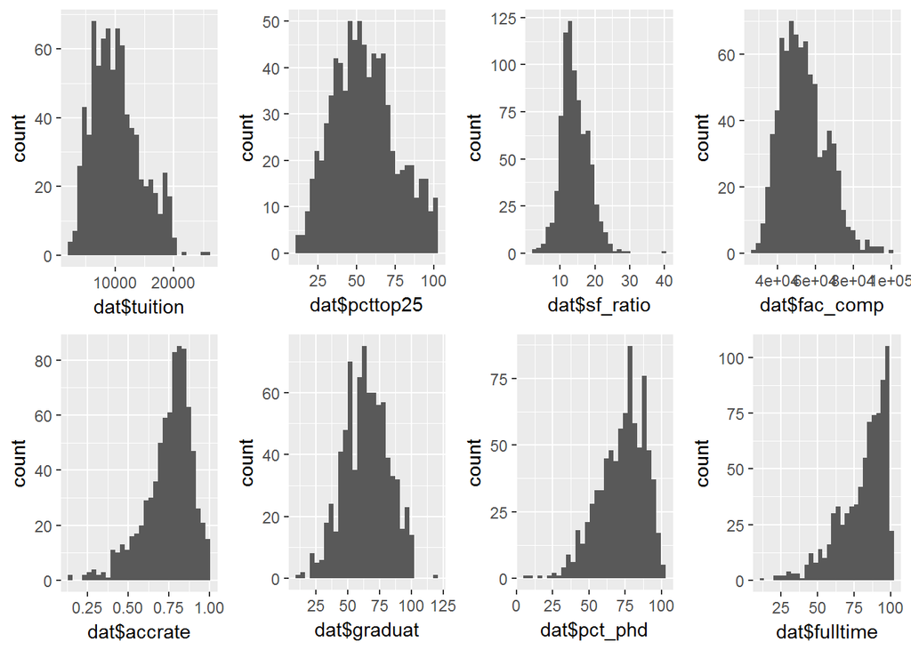

sf_ratio,tuition and graduat can be seen having outliers.Cleaning the outliers by deleting the 1st and 99th percentiles of datapoints with respect to these variables

## Replotting data to see if outliers are removed

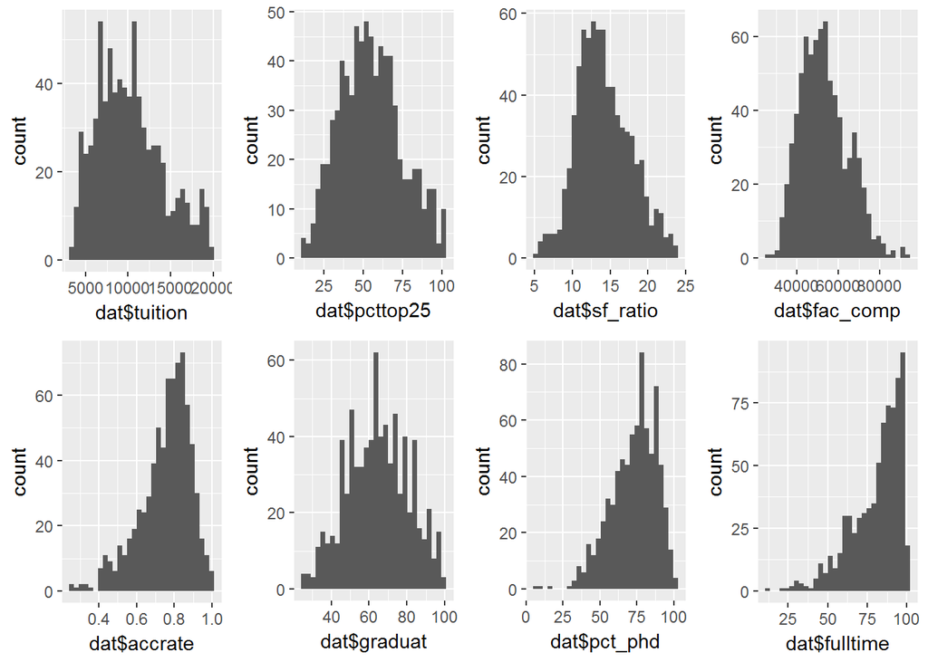

All outliers are removed.

# Fitting Regression model

```
##
## Call:
## lm(formula = tuition ~ ., data = dat)
##
## Residuals:
##     Min      1Q  Median      3Q     Max
## -7817.5 -1204.8     5.7  1225.5  6189.9
##
## Coefficients:
##                  Estimate Std. Error t value Pr(>|t|)
## (Intercept)    -3.068e+03  9.809e+02  -3.128  0.00183 **
## pcttop25       -3.780e+00  5.209e+00  -0.726  0.46823
## sf_ratio       -1.909e+02  2.551e+01  -7.485 2.04e-13 ***
## fac_comp        1.329e-01  1.014e-02  13.109  < 2e-16 ***
## accrate         3.966e+02  6.401e+02   0.620  0.53567
## graduat         3.258e+01  6.051e+00   5.385 9.76e-08 ***
## pct_phd         3.269e+01  6.807e+00   4.802 1.90e-06 ***
## fulltime        1.240e+01  5.113e+00   2.425  0.01556 *
## alumni          4.260e+01  7.586e+00   5.615 2.78e-08 ***
## num_enrl       -3.206e-01  1.088e-01  -2.947  0.00331 **
## public.private  3.874e+03  2.494e+02  15.531  < 2e-16 ***
## ---
## Signif. codes:  0 '***' 0.001 '**' 0.01 '*' 0.05 '.' 0.1 ' ' 1
##
## Residual standard error: 1982 on 739 degrees of freedom
## Multiple R-squared:  0.7419, Adjusted R-squared:  0.7384
## F-statistic: 212.4 on 10 and 739 DF,  p-value: < 2.2e-16
```

A linear regression model is fit between tuition and all the variables.From the p values, there are certain variables which do not have significant effect on the tuition and thus have very high values which can be eliminated.There could be an increase in the adjusted R squared value and more importantly the dimensionality reduces.The problem of overfitting also can be solved by selecting the required features.

## Model selection in R

we can perform forward subset selection,backward subset selection or both to find the best Linear regression model.The step function in R helps in applying the algorithms automatically.

### Fitting empty model

```
##
## Call:
## lm(formula = tuition ~ 1, data = dat)
##
## Coefficients:
## (Intercept)
##       10235
```

```
##
## Call:
## lm(formula = tuition ~ 1, data = dat)
##
## Residuals:
##     Min      1Q  Median      3Q     Max
## -6960.8 -2992.3  -372.8  2442.4  9465.2
##
## Coefficients:
##             Estimate Std. Error t value Pr(>|t|)
## (Intercept)  10234.8      141.5   72.35   <2e-16 ***
## ---
## Signif. codes:  0 '***' 0.001 '**' 0.01 '*' 0.05 '.' 0.1 ' ' 1
##
## Residual standard error: 3874 on 749 degrees of freedom
```

### Fitting full model

```
##
## Call:
## lm(formula = tuition ~ ., data = dat)
##
## Coefficients:
##    (Intercept)        pcttop25        sf_ratio        fac_comp
##     -3067.7294         -3.7805       -190.9014          0.1329
##        accrate         graduat         pct_phd        fulltime
##       396.6351         32.5841         32.6917         12.3981
##         alumni        num_enrl  public.private
##        42.5978         -0.3206       3873.6892
```

## Forward selection

The step function starts from 0 variable model and adds a variable and checks the AIC value.It then adds anothe variable and determines the AIC value and compares it with the model, if the AIC value is higher it drops the variable and picks up another variable.The function performs this by adding and dropping variables from the model depending on the AIC values. It selects the model which has the lowest AIC value.

```
## Start:  AIC=12394.14
## tuition ~ 1
##
##                  Df  Sum of Sq        RSS   AIC
## + graduat         1 4137097089 7.1049e+09 12052
## + public.private  1 4016195817 7.2258e+09 12065
## + sf_ratio        1 3665920476 7.5761e+09 12100
## + alumni          1 3459265508 7.7828e+09 12120
## + pcttop25        1 2132497238 9.1095e+09 12238
## + fac_comp        1 1433227516 9.8088e+09 12294
## + pct_phd         1 1427339592 9.8147e+09 12294
## + fulltime        1  641981387 1.0600e+10 12352
## + num_enrl        1  493730084 1.0748e+10 12362
## + accrate         1  392183153 1.0850e+10 12370
## <none>                         1.1242e+10 12394
##
## Step:  AIC=12051.99
## tuition ~ graduat
##
##                  Df  Sum of Sq        RSS   AIC
## + sf_ratio        1 1603246100 5501681243 11862
## + public.private  1 1567036741 5537890601 11867
## + alumni          1  983741930 6121185412 11942
## + pct_phd         1  489478749 6615448593 12000
## + fac_comp        1  487745259 6617182084 12001
## + pcttop25        1  367706660 6737220682 12014
## + num_enrl        1  309806885 6795120458 12020
## + fulltime        1   90210885 7014716457 12044
## + accrate         1   26275371 7078651971 12051
## <none>                         7104927342 12052
##
## Step:  AIC=11862.18
## tuition ~ graduat + sf_ratio
##
##                  Df Sum of Sq        RSS   AIC
## + fac_comp        1 649949863 4851731380 11770
## + public.private  1 567467310 4934213933 11782
## + pct_phd         1 560951023 4940730220 11784
## + alumni          1 415567144 5086114098 11805
## + pcttop25        1 242771688 5258909555 11830
```

[output cut: 55 more lines]

```
##
##            Df Sum of Sq        RSS   AIC
## + fulltime  1  21287347 2906431123 11396
## <none>                  2927718470 11399
## + accrate   1   2544701 2925173768 11400
## + pcttop25  1    559047 2927159423 11401
##
## Step:  AIC=11395.59
## tuition ~ graduat + sf_ratio + fac_comp + public.private + alumni +
##     pct_phd + num_enrl + fulltime
##
##            Df Sum of Sq        RSS   AIC
## <none>                  2906431123 11396
## + pcttop25  1   3019940 2903411183 11397
## + accrate   1   2459576 2903971547 11397
```

```
##
## Call:
## lm(formula = tuition ~ graduat + sf_ratio + fac_comp + public.private +
##     alumni + pct_phd + num_enrl + fulltime, data = dat)
##
## Coefficients:
##    (Intercept)         graduat        sf_ratio        fac_comp
##     -2590.7418         31.1678       -188.3291          0.1292
## public.private          alumni         pct_phd        num_enrl
##      3889.9308         41.6960         31.8248         -0.3198
##       fulltime
##        11.6336
```

## Final model after forward selection

```
##
## Call:
## lm(formula = tuition ~ graduat + sf_ratio + fac_comp + public.private +
##     alumni + pct_phd + num_enrl + fulltime, data = dat)
##
## Residuals:
##     Min      1Q  Median      3Q     Max
## -7849.0 -1201.7    -0.9  1263.9  6280.5
##
## Coefficients:
##                  Estimate Std. Error t value Pr(>|t|)
## (Intercept)    -2.591e+03  7.331e+02  -3.534 0.000435 ***
## graduat         3.117e+01  5.902e+00   5.281 1.69e-07 ***
## sf_ratio       -1.883e+02  2.535e+01  -7.428 3.04e-13 ***
## fac_comp        1.292e-01  9.453e-03  13.669  < 2e-16 ***
## public.private  3.890e+03  2.456e+02  15.838  < 2e-16 ***
## alumni          4.170e+01  7.491e+00   5.566 3.64e-08 ***
## pct_phd         3.182e+01  6.663e+00   4.776 2.15e-06 ***
## num_enrl       -3.198e-01  1.069e-01  -2.992 0.002861 **
## fulltime        1.163e+01  4.994e+00   2.330 0.020093 *
## ---
## Signif. codes:  0 '***' 0.001 '**' 0.01 '*' 0.05 '.' 0.1 ' ' 1
##
## Residual standard error: 1980 on 741 degrees of freedom
## Multiple R-squared:  0.7415, Adjusted R-squared:  0.7387
## F-statistic: 265.6 on 8 and 741 DF,  p-value: < 2.2e-16
```

## Backward selection

It is same as that of forward selection, but in this case it drops variables starting from a full model.

```
## Start:  AIC=11398.42
## tuition ~ pcttop25 + sf_ratio + fac_comp + accrate + graduat +
##     pct_phd + fulltime + alumni + num_enrl + public.private
##
##                  Df Sum of Sq        RSS   AIC
## - accrate         1   1507821 2903411183 11397
## - pcttop25        1   2068185 2903971547 11397
## <none>                        2901903362 11398
## - fulltime        1  23087173 2924990534 11402
## - num_enrl        1  34108108 2936011470 11405
## - pct_phd         1  90565052 2992468413 11420
## - graduat         1 113853491 3015756852 11425
## - alumni          1 123811309 3025714670 11428
## - sf_ratio        1 219979287 3121882649 11451
## - fac_comp        1 674791275 3576694637 11553
## - public.private  1 947192219 3849095580 11608
##
## Step:  AIC=11396.81
## tuition ~ pcttop25 + sf_ratio + fac_comp + graduat + pct_phd +
##     fulltime + alumni + num_enrl + public.private
##
##                  Df Sum of Sq        RSS   AIC
## - pcttop25        1   3019940 2906431123 11396
## <none>                        2903411183 11397
## - fulltime        1  23748240 2927159423 11401
## - num_enrl        1  32711577 2936122760 11403
## - pct_phd         1  92494229 2995905412 11418
## - graduat         1 112347001 3015758183 11423
## - alumni          1 124535162 3027946345 11426
## - sf_ratio        1 219395289 3122806472 11449
## - fac_comp        1 719171780 3622582963 11561
## - public.private  1 986810594 3890221776 11614
##
## Step:  AIC=11395.59
## tuition ~ sf_ratio + fac_comp + graduat + pct_phd + fulltime +
##     alumni + num_enrl + public.private
##
##                  Df Sum of Sq        RSS   AIC
## <none>                        2906431123 11396
## - fulltime        1  21287347 2927718470 11399
## - num_enrl        1  35118666 2941549789 11403
## - pct_phd         1  89486131 2995917254 11416
## - graduat         1 109376000 3015807123 11421
## - alumni          1 121516580 3027947703 11424
## - sf_ratio        1 216425374 3122856497 11448
## - fac_comp        1 732903975 3639335097 11562
## - public.private  1 983932184 3890363307 11612
```

```
##
## Call:
## lm(formula = tuition ~ sf_ratio + fac_comp + graduat + pct_phd +
##     fulltime + alumni + num_enrl + public.private, data = dat)
##
## Coefficients:
##    (Intercept)        sf_ratio        fac_comp         graduat
##     -2590.7418       -188.3291          0.1292         31.1678
##        pct_phd        fulltime          alumni        num_enrl
##        31.8248         11.6336         41.6960         -0.3198
## public.private
##      3889.9308
```

Same model obtained as obtained by forward elimination.

# Final model

The p values of all selected variables are less than 0.05 which suggests that all the variables have significant effect on the tuition.Though the improvement in R squared value is not very significant, we have obtained reduced dimensionality which is important and valuable in case of large datasets.

```
##
## Call:
## lm(formula = tuition ~ graduat + sf_ratio + fac_comp + public.private +
##     alumni + pct_phd + num_enrl + fulltime, data = dat)
##
## Residuals:
##     Min      1Q  Median      3Q     Max
## -7849.0 -1201.7    -0.9  1263.9  6280.5
##
## Coefficients:
##                  Estimate Std. Error t value Pr(>|t|)
## (Intercept)    -2.591e+03  7.331e+02  -3.534 0.000435 ***
## graduat         3.117e+01  5.902e+00   5.281 1.69e-07 ***
## sf_ratio       -1.883e+02  2.535e+01  -7.428 3.04e-13 ***
## fac_comp        1.292e-01  9.453e-03  13.669  < 2e-16 ***
## public.private  3.890e+03  2.456e+02  15.838  < 2e-16 ***
## alumni          4.170e+01  7.491e+00   5.566 3.64e-08 ***
## pct_phd         3.182e+01  6.663e+00   4.776 2.15e-06 ***
## num_enrl       -3.198e-01  1.069e-01  -2.992 0.002861 **
## fulltime        1.163e+01  4.994e+00   2.330 0.020093 *
## ---
## Signif. codes:  0 '***' 0.001 '**' 0.01 '*' 0.05 '.' 0.1 ' ' 1
##
## Residual standard error: 1980 on 741 degrees of freedom
## Multiple R-squared:  0.7415, Adjusted R-squared:  0.7387
## F-statistic: 265.6 on 8 and 741 DF,  p-value: < 2.2e-16
```